# Arbeidskrav 4: Repeated measures studies

Johannes Urdahl Haugen

11/20/2020

## Del 1

### Bakgrunn

Innenfor styrketrening finnes det mange ulike teorier om hvilken intensitet man burde trene på for å bli sterkest mulig. Noen mener mange repetisjoner med lettere vekter er den riktige måten å trene på, andre mener få repetisjoner med tunge vekter er mest effektivt. I del 1 av denne oppgaven skal jeg forsøke å svare på hvilken intensitet man burde trene på for å øke styrken i benkpress. Tallene jeg bruker i analysen er hentet fra pre-test og post-test.

Det var totalt 24 forsøkspersoner med i studien. 11 personer gjennomførte økter med 30 repetisjoner, 13 forsøkspersoner gjennomførte økter med 10 repetisjoner. Belastningen var slik at forsøkspersonen var utslitt etter henholdsvis 10 og 30 repetisjoner (10RM og 30RM). Det vil si at forsøkspersonene i 10RM gruppa trente med tyngre vekter enn forsøkspersonene i 30RM gruppa. Tabell 1 viser hvordan endringene var fra pre-test til post-test i de to gruppene.

| Tabell 1: Endringer fra pre til post-test Gruppe | Tabell 1: Endringer fra pre til post-test Gjennomsnittlig endring (kg) | Tabell 1: Endringer fra pre til post-test Standardavvik |
| --- | --- | --- |
| RM10 | 9.72 | 5.01 |
| RM30 | 6.14 | 4.71 |

### Metode

Tabell 1 viste en høyere gjennomsnittlig endring i RM10 gruppa, men for å se på om denne forskjellen er signifikant må det gjennomføres en statistisk analyse. Til å gjennomføre analysen har jeg valgt å bruke en ANCOVA-modell. I denne modellen bruker jeg pre-test verdiene som covariate for å justere for eventuelle forskjeller før intervensjonsperioden. Jeg er ute etter forskjellene i de to gruppene etter intervensjonsperioden(post-test).

Første steg er å sjekke om det er en lineær sammenheng mellom de to gruppene. For å teste dette brukes et enkelt scatter-plot. Figur 1 viser at det er en lineær sammenheng mellom de to gruppene.

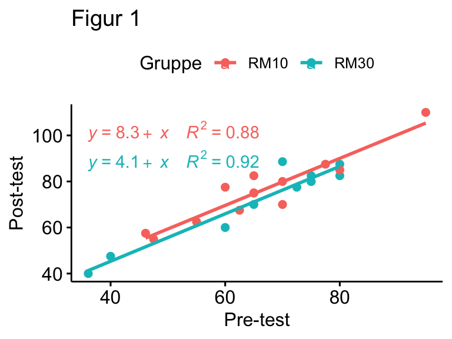

Homogeniteten i mellom de to regresjonene ble testet ved hjelp av en enkel anova-test. Denne ga en p-verdi på 0.952. Denne var ikke statistisk signifikant og vil si at det er homogenitet i mellom de to regresjonene.

Normaliteten av residualene ble testet ved hjelp av en shapiro-test. Denne ga en p-verdi på 0.1843926. I og med at denne p-verdien ikke var statistisk signifikant antar vi normalitet mellom residualene.

Homoskedastisiteten ble testet ved hjelp av en levene test. Denne ga en p-verdi på 0.5668168 og var ikke signifikant.

Ekstreme verdier er noe vi ønsker å unngå når vi jobber med statistisk analyse fordi disse potensielt kan påvirke resultatene. Ved en enkel test ble det ikke funnet noen ekstreme verdier i dette datasettet.

Til slutt ble resultatet regnet ut ved at effektene til covariaten (pre-test) ble fjernet og anova-testen ble gjennomført. Tabell 2 viser resultatene av analysen.

### Resultater

| Tabell 2: Resultater fra ANCOVA-modellen Effekt | Tabell 2: Resultater fra ANCOVA-modellen DFn | Tabell 2: Resultater fra ANCOVA-modellen DFd | Tabell 2: Resultater fra ANCOVA-modellen F | Tabell 2: Resultater fra ANCOVA-modellen P-verdi | Tabell 2: Resultater fra ANCOVA-modellen p<.05 | Tabell 2: Resultater fra ANCOVA-modellen ges |
| --- | --- | --- | --- | --- | --- | --- |
| pre | 1 | 21 | 187.881 | 0.000 |  | 0.899 |
| group | 1 | 21 | 3.105 | 0.093 |  | 0.129 |

Tabell 2 viser resultatene fra ANCOVA-modellen. P-verdien var 0.093, altså ikke signifikant (p > 0.05). Figur 2 viser resultatene visuelt.

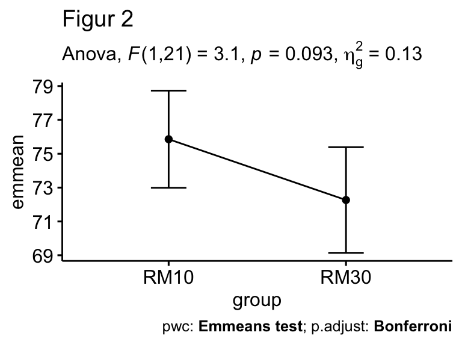

### Diskusjon

Resultatene fra den statistiske analysen viste at det ikke er grunnlag for å si at færre repetisjoner er bedre for styrke enn få repetisjoner. P-verdien på 0.093 var ikke signifikant i dette tilfellet. Likevel finnes det motstridende forskninge på dette området.

Schoenfeld et al. (2017) gjennomførte en meta-analyse på dette området. De fant at færre repetisjoner med høyere motstand ga bedre effekt på styrke enn mange repetisjoner med lav motstand.

Schoenfeld et al. (2015) gjennomførte en studie på godt trente menn. De sammenlignet effekten av høy motstand, få repetisjoner og lav motstand, mange repetisjoner. Konklusjonen ble at færre repetisjoner var best for å øke styrken, men det var ingen tydelig forskjell på muskelvekst.

Dataene i min analyse indikerer det samme, men de var ikke signifikante. Fra tabell 1 ser vi at gruppen med færre repitisjoner hadde større endring enn gruppa med mange repetisjoner. Årsaken til at jeg ikke fikk et signifkant resultat er usikkert, men det kan være på grunn av for lite data. Hadde jeg analysert hele datasettet og ikke kun fokusert på benkpress kunne resultatet kanskje vært annerledes.

## Del 2

### Bakgrunn

Innenfor styrketrening finnes det ulike teorier om hvor mange sett man burde gjennomføre for å størst effekt. Noen mener mange flere sett lønner seg, andre mener ett sett er nok. I del 2 av denne oppgaven skal jeg forsøke å svare på hvor mange sett man burde ha i en øvelse for å øke styrken mest effektivt. Tallene jeg bruker i analysen er hentet fra pre-test og post-test.

| Tabell 1: Endringer fra pre til post-test Gruppe | Tabell 1: Endringer fra pre til post-test Gjennomsnittlig endring | Tabell 1: Endringer fra pre til post-test Standardavvik |
| --- | --- | --- |
| multiple | 33.95 | 25.58 |
| single | 19.73 | 24.67 |

### Metode

Tabell 1 viste en høyere gjennomsnittlig endring i 3 sett gruppa, men for å se på om denne forskjellen er signifikant må det gjennomføres en statistisk analyse. Til å gjennomføre analysen har jeg valgt å bruke en ANCOVA-modell. I denne modellen bruker jeg pre-test verdiene som covariate for å justere for eventuelle forskjeller før intervensjonsperioden. Jeg er ute etter forskjellene i de to gruppene etter intervensjonsperioden(post-test).

Første steg er å sjekke om det er en lineær sammenheng mellom de to gruppene. For å teste dette brukes et enkelt scatter-plot. Figur 1 viser at det er en lineær sammenheng mellom de to gruppene.

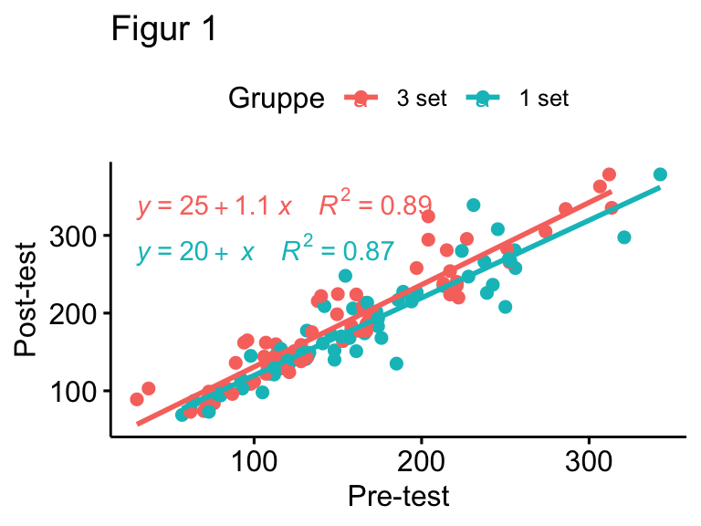

Homogeniteten i mellom de to regresjonene ble testet ved hjelp av en enkel anova-test. Denne ga en p-verdi på 0.379. Denne var ikke statistisk signifikant og vil si at det er homogenitet i mellom de to regresjonene.

Homoskedastisiteten ble testet ved hjelp av en levene test. Denne ga en p-verdi på 0.1721418 og var ikke signifikant.

Ekstreme verdier er noe vi ønsker å unngå når vi jobber med statistisk analyse fordi disse potensielt kan påvirke resultatene. Ved en enkel test ble det funnet 2 ekstreme verdier i dette datasettet. Hver gruppe hadde en ekstrem verdi. Disse ble med i analysen (mest fordi undertegnede ikke fant en god løsning på å fjerne dem, hehe).

Til slutt ble resultatet regnet ut ved at effektene til covariaten (pre-test) ble fjernet og anova-testen ble gjennomført. Tabell 2 viser resultatene av analysen.

### Resultater

| Tabell 2: Resultater fra ANCOVA-modellen Effekt | Tabell 2: Resultater fra ANCOVA-modellen DFn | Tabell 2: Resultater fra ANCOVA-modellen DFd | Tabell 2: Resultater fra ANCOVA-modellen F | Tabell 2: Resultater fra ANCOVA-modellen P-verdi | Tabell 2: Resultater fra ANCOVA-modellen p<.05 | Tabell 2: Resultater fra ANCOVA-modellen ges |
| --- | --- | --- | --- | --- | --- | --- |
| pre | 1 | 131 | 933.457 | 0.000 |  | 0.877 |
| group | 1 | 131 | 10.886 | 0.001 |  | 0.077 |

Tabell 2 viser resultatene fra ANCOVA-modellen. P-verdien var 0.001. Dette er en signifikant verdi (p < 0.05). Figur 2 viser resultatene visuelt.

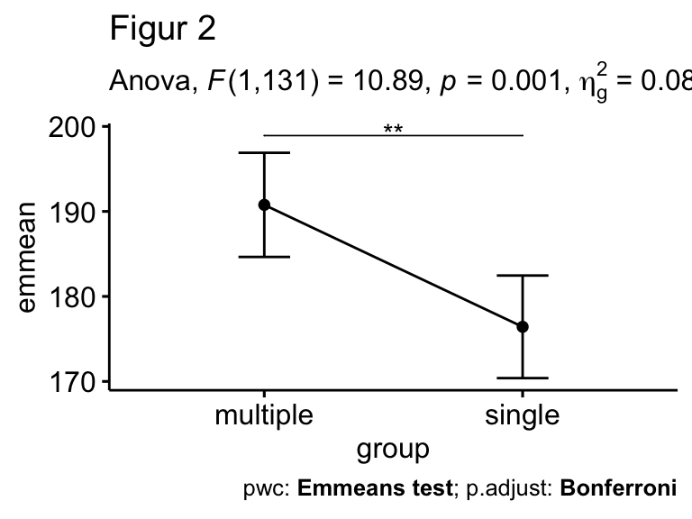

### Diskusjon

Resultatene fra den statistiske analysen viste at det er grunnlag for å si at flere sett er bedre for å øke styrke enn kun ett sett . P-verdien på 0.001 var signifikant. I litteraturen finnes det flere eksempler som støtter disse funnene.

Humburg et al. (2007) gjennomførte en crossover-studie som så på forskjellen ved 1 sett styrketrening og 3 sett styrketrening. Denne studien ble gjort på utrente menn og kvinner. I første treningsperiode trente de i 9 uker med kun 1 sett per øvelse. Etter de første 9 ukene hadde de en 9 ukers hvileperiode før de gjennomførte 9 uker med 3 sett per øvelse. Denne studien viste antydning til at flere sett er mer effektivt for å øke styrke.

Schlumberger et al. (2001) gjennomførte en studie på 27 kvinner og ønsket å undersøke forskjellen på 1 sett og 3 sett styrketrening. Det ble gjennomført 2 økter i uken i 6 uker. Studien viste bedre effekt på styrketrening med 3 sett.

Ut i fra litteraturen kan vi være ganske sikre på at resultatene fra den statistiske analysen stemmer. Det er likevel vanskelig å komme til en tydelig konklusjon da jeg ikke har nok informasjon om gjennomføring av denne studien. Dataene viser en signifikant forskjell mellom 3 sett og 1 sett styrketrening, hvor 3 sett gir best effekt.

## Referanser

Humburg, H., Baars, H., Schröder, J., Reer, R. & Braumann, K. M. (2007). 1-Set vs. 3-set resistance training: a crossover study. J Strength Cond Res, 21(2), 578-582. https://doi.org/10.1519/r-21596.1

Schlumberger, A., Stec, J. & Schmidtbleicher, D. (2001). Single- vs. multiple-set strength training in women. J Strength Cond Res, 15(3), 284-289.

Schoenfeld, B. J., Grgic, J., Ogborn, D. & Krieger, J. W. (2017). Strength and Hypertrophy Adaptations Between Low- vs. High-Load Resistance Training: A Systematic Review and Meta-analysis. J Strength Cond Res, 31(12), 3508-3523. https://doi.org/10.1519/jsc.0000000000002200

Schoenfeld, B. J., Peterson, M. D., Ogborn, D., Contreras, B. & Sonmez, G. T. (2015). Effects of Low- vs. High-Load Resistance Training on Muscle Strength and Hypertrophy in Well-Trained Men. J Strength Cond Res, 29(10), 2954-2963. https://doi.org/10.1519/jsc.0000000000000958